# RQ3 Data — Human Import, Merge, and Descriptives

Human participant data · AI–human merge · Matched condition

Author

Caroline Müller

Published

May 17, 2026

# 1 Overview

**Prerequisite:** Run `10_RQ2_data.qmd` first to generate `d_rq3_ai.rds`, `tbl_icc_raw.rds`, and `tbl_word_count_by_condition.rds` in `10_data/80_analyses_exports/`.

This file covers:

- Import and quality-check of human participant CSV
- Questionnaire composites (autonomy: 4 items; competence: 4 items; relatedness: **5 items** — differs from AI surrogates)
- Merge with matched AI surrogate condition (short-3: target_words = 50, text_count = 3)
- Descriptive comparison (demographics, Q scores, LLM scores)
- Export of `d_rq3_merged.rds` and `d_human_clean.rds`

**Note on relatedness items:** human participants completed 5 relatedness items (rel1–rel5); AI surrogate composites use 4 items. The composite means (`q_rel_mean`) are therefore not strictly comparable at the item level, but are on the same 1–5 scale. This is acknowledged in all comparisons.

# 2 Setup

## 2.1 Environment

## 2.2 Shared Constants

## 2.3 Load Upstream Exports

# 3 Human Data Import

## 3.1 Import Raw CSV

## 3.2 Import Audit

Table 1: Human Data Import Audit

| Metric | Value |
| --- | --- |
| Source file | humans_2026-04-13.csv |
| Total rows | 132 |
| Expected columns | participant_id, gender, birthyear, education, aut1-4, comp1-4, rel1-5, PVQ_M/K_1-21, llm_*_rep1-3, wc_* |
| Actual columns | 72 |
| Q aut items | aut1-4 present |
| Q com items | comp1-4 present |
| Q rel items | rel1-5 present (5 items) |
| LLM aut columns | llm_aut_rep1-3 present |
| LLM com columns | llm_com_rep1-3 present |
| LLM rel columns | llm_rel_rep1-3 present |
| Word count col | wc_total present |
| Duplicate IDs | 0 |

Note. Column presence gates — any MISSING entry would indicate a pipeline change in the source file.

## 3.3 Data Quality Checks

## 3.4 Type Conversion, Rename, Drop PVQ

## 3.5 Age Computation

## 3.6 Questionnaire Composites

**Item counts:** autonomy = 4 items, competence = 4 items, relatedness = **5 items** (rel1–rel5). The relatedness composite for human participants therefore averages 5 items, compared to 4 for AI surrogates. Both are on the same 1–5 scale.

## 3.7 LLM Composite Means

# 4 Merge AI + Human

## 4.1 Matched AI Condition

`d_rq3_ai.rds` was filtered to short-3 (target_words = 50, text_count = 3) in `10_RQ2_data.qmd`. Verify the condition before merging.

## 4.2 Merge

## 4.3 Word Count Match Verification

Table 2: Word Count Comparison: AI Surrogates (Short-3) vs Human Participants

| Sample | N | M | SD | Mdn | Min | Max |
| --- | --- | --- | --- | --- | --- | --- |
| AI surrogates | 394 | 152.1 | 6.2 | 153 | 128 | 166 |
| Humans | 132 | 184.8 | 57.5 | 166 | 131 | 506 |

Note. Actual words = total word count across all 3 scored texts. AI surrogates: short-3 condition (target = 50 words per text, 3 texts). Human participants wrote 3 texts targeting ~50 words each.

# 5 Descriptives: Demographics (Human)

Table 3: Human Participant Demographics

| Characteristic | Value |
| --- | --- |
| N | 132 |
| Age: M (SD) | 38.4 (9.8) |
| Age: range | [18, 62] |
| Gender distribution | Male: n = 72 (54.5%); Female: n = 60 (45.5%) |
| Education distribution | Level 1: n = 1 (0.8%); Level 2: n = 5 (3.8%); Level 3: n = 33 (25%); Level 4: n = 23 (17.4%); Level 5: n = 34 (25.8%); Level 6: n = 33 (25%); Level 8: n = 3 (2.3%) |

# 6 Descriptives: Questionnaire Scores

## 6.1 Summary Table by Group

Table 4: Questionnaire Score Descriptives by Group and Need Dimension

| Need | Sample | n | M | SD | Mdn | Min | Max | Skew | Kurt |
| --- | --- | --- | --- | --- | --- | --- | --- | --- | --- |
| Autonomy | AI surrogates | 394 | 3.24 | 0.49 | 3.25 | 2.00 | 4.5 | 0.00 | -0.30 |
|  | Humans | 132 | 3.61 | 0.71 | 3.50 | 1.00 | 5.0 | -0.22 | 0.47 |
| Competence | AI surrogates | 394 | 4.19 | 0.34 | 4.00 | 3.25 | 5.0 | 0.32 | -0.52 |
|  | Humans | 132 | 3.75 | 0.72 | 3.75 | 1.25 | 5.0 | -0.74 | 0.88 |
| Relatedness | AI surrogates | 394 | 3.86 | 0.42 | 4.00 | 2.25 | 5.0 | -0.30 | 2.21 |
|  | Humans | 132 | 3.62 | 0.74 | 3.60 | 1.00 | 5.0 | -0.32 | 0.41 |

Note. All scores on a 1–5 scale. Skew = Fisher's skewness; Kurt = excess kurtosis. Human q_rel_mean averages 5 items; AI q_rel_mean averages 4 items.

## 6.2 Distribution by Group

Figure 1: Questionnaire Score Distributions by Group and Need Dimension. Violin + boxplot. AI surrogates (blue) vs human participants (red).

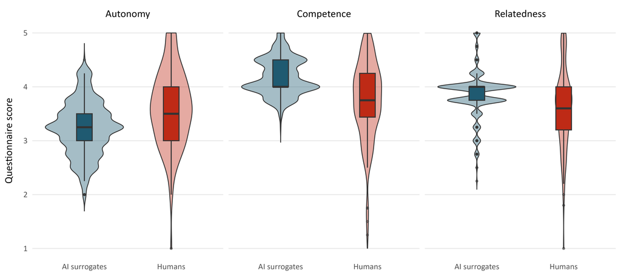

# 7 Descriptives: LLM Scores

## 7.1 Summary Table by Group

Table 5: LLM Score Descriptives by Group and Need Dimension

| Need | Sample | n | M | SD | Mdn | Min | Max | Skew | Kurt |
| --- | --- | --- | --- | --- | --- | --- | --- | --- | --- |
| Autonomy | AI surrogates | 394 | 2.94 | 0.40 | 3 | 2.00 | 4.67 | -0.25 | 2.84 |
|  | Humans | 132 | 2.66 | 0.64 | 3 | 2.00 | 4.67 | 0.60 | -0.30 |
| Competence | AI surrogates | 394 | 3.41 | 0.47 | 3 | 2.33 | 4.67 | 0.36 | -1.60 |
|  | Humans | 132 | 2.58 | 0.55 | 3 | 1.00 | 4.00 | 0.00 | -0.69 |
| Relatedness | AI surrogates | 394 | 3.07 | 0.40 | 3 | 2.00 | 4.00 | 0.37 | 2.35 |
|  | Humans | 132 | 3.42 | 0.54 | 3 | 2.00 | 5.00 | 0.01 | -0.65 |

Note. LLM score = mean of 3 scoring repeats. All scores on a 1–5 scale. Skew = Fisher's skewness; Kurt = excess kurtosis.

## 7.2 LLM Score Distributions by Group

Figure 2: LLM Score Distributions by Group and Need Dimension. Violin + boxplot. AI surrogates (blue) vs human participants (red).

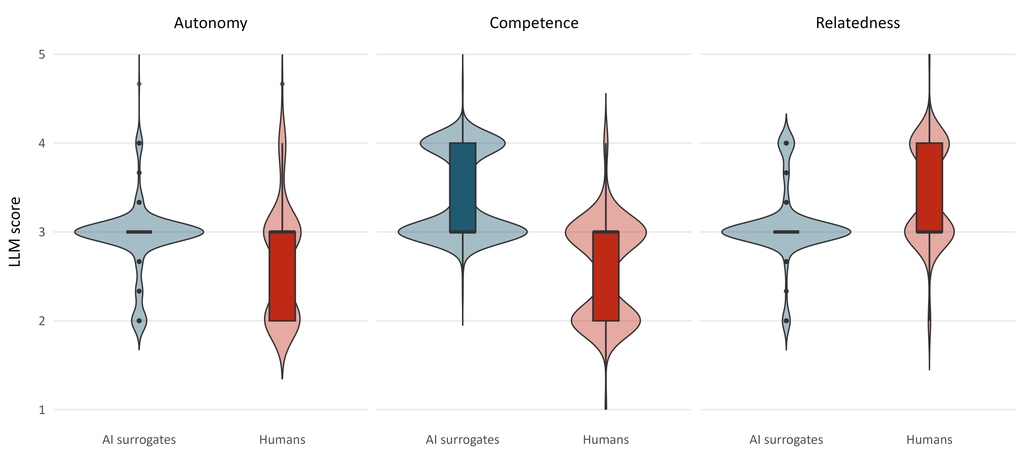

## 7.3 LLM vs Questionnaire Scatter by Group

Figure 3: LLM score vs questionnaire score by group and need dimension. LOESS (solid) and OLS (dashed) overlays. Supports assumption check for RQ3b.

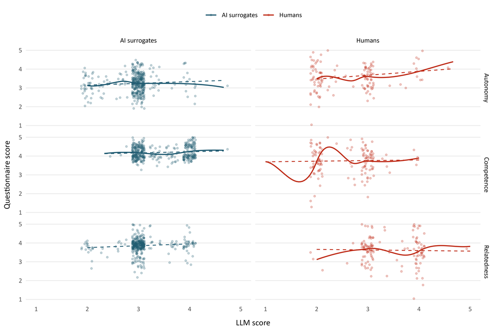

# 8 Exports

# 9 Session Info